# NHANES EDA — Demographics & Nutrients

Gender Protein Consumption

2025-10-21

**Setup (packages, paths, global options)**

```r
# knitr / plot options for clean writeup
#show code but hide noisy messages in the doc
knitr::opts_chunk$set(
  echo = TRUE,       # show code
  message = FALSE,   # hide package startup messages
  warning = FALSE,   # hide warnings in the doc
  fig.width = 7,
  fig.height = 5,
  fig.align = "center"
)
```

## Overview

This skript first shows a quick EDA of the NHANES Day-1 dietary recalls plus a focused hypothesis test on protein by gender.

*Load processed analysis file* Below we load the processed parquet we created earlier (proc_data/demo_foods.parquet) and do a quick sanity check so we know what’s in memory.

```r
# NOTE: the file should be in the working dir of the proc data or adjust the path
getwd()
```

```
## [1] "/Users/marlon/DataScienceProject/proc_data"
```

```r
# this is the processed file we created earlier in the pipeline
food <- read_parquet("demo_foods.parquet")

# quick peek to make sure it loaded
head(food)
```

| SEQN | RIAGENDR | RIDAGEYR | RIDRETH1 | RIDRETH3 | DMDEDUC2 | DMDMARTZ | DMDHHSIZ | WTINT2YR | INDFMPIR | WTDRD1 | DR1IGRMS_sum | DR1IGRMS_mean | DR1IGRMS_sd | DR1IKCAL_sum | DR1IKCAL_mean | DR1IKCAL_sd | DR1IPROT_sum | DR1IPROT_mean | DR1IPROT_sd | DR1ICARB_sum | DR1ICARB_mean | DR1ICARB_sd | DR1ISUGR_sum | DR1ISUGR_mean | DR1ISUGR_sd | DR1IFIBE_sum | DR1IFIBE_mean | DR1IFIBE_sd | DR1ITFAT_sum | … |
| --- | --- | --- | --- | --- | --- | --- | --- | --- | --- | --- | --- | --- | --- | --- | --- | --- | --- | --- | --- | --- | --- | --- | --- | --- | --- | --- | --- | --- | --- | --- |
| 130378 | 1 | 43 | 5 | 6 | 5 | 1 | 4 | 50055.45 | 5.00 | 61366.56 | 3662.08 | 215.4165 | 248.4808 | 1740 | 102.3529 | 161.3145 | 80.46 | 4.732941 | 11.648284 | 169.66 | 9.980000 | 20.80911 | 43.71 | 2.571176 | 7.705709 | 10.1 | 0.5941176 | 1.2507351 | 55.07 | … |
| 130379 | 1 | 66 | 3 | 3 | 5 | 1 | 2 | 29087.45 | 5.00 | 34638.06 | 4697.95 | 223.7119 | 172.2624 | 2741 | 130.5238 | 135.8428 | 86.45 | 4.116667 | 7.032840 | 314.86 | 14.993333 | 16.73971 | 113.58 | 5.408571 | 6.452790 | 29.6 | 1.4095238 | 1.5987197 | 67.18 | … |
| 130380 | 2 | 44 | 2 | 2 | 3 | 1 | 7 | 80062.67 | 1.41 | 84728.26 | 4537.50 | 252.0833 | 221.6390 | 1995 | 110.8333 | 190.9602 | 69.86 | 3.881111 | 8.472066 | 281.67 | 15.648333 | 23.12733 | 114.66 | 6.370000 | 15.137689 | 21.1 | 1.1722222 | 2.6801680 | 65.38 | … |
| 130386 | 1 | 34 | 1 | 1 | 4 | 1 | 3 | 30995.28 | 1.33 | 82013.37 | 3592.80 | 359.2800 | 564.2252 | 2422 | 242.2000 | 263.7662 | 132.41 | 13.241000 | 15.358724 | 207.53 | 20.753000 | 28.23172 | 37.89 | 3.789000 | 6.690166 | 25.1 | 2.5100000 | 3.5196117 | 116.54 | … |
| 130387 | 2 | 68 | 3 | 3 | 5 | 3 | 1 | 19896.97 | 1.32 | 20032.62 | 3589.52 | 163.1600 | 132.7417 | 3849 | 174.9545 | 255.7598 | 68.93 | 3.133182 | 7.385364 | 376.54 | 17.115455 | 16.76748 | 227.99 | 10.363182 | 12.638535 | 22.0 | 1.0000000 | 1.4445299 | 234.39 | … |
| 130389 | 1 | 59 | 3 | 3 | 5 | 1 | 2 | 28876.54 | 5.00 | 79000.19 | 2837.35 | 189.1567 | 385.2840 | 1991 | 132.7333 | 175.8544 | 89.50 | 5.966667 | 11.494413 | 118.64 | 7.909333 | 10.05260 | 52.67 | 3.511333 | 6.468854 | 6.7 | 0.4466667 | 0.6010309 | 98.03 | … |

```r
# Relabel key nutrient totals for easier plotting (MUST come before plots)
nutrient_df <- food |>
  rename(
    `Calories (kcal)`   = DR1IKCAL_sum,
    `Protein (g)`       = DR1IPROT_sum,
    `Carbohydrates (g)` = DR1ICARB_sum,
    `Sugars (g)`        = DR1ISUGR_sum,
    `Fiber (g)`         = DR1IFIBE_sum,
    `Total Fat (g)`     = DR1ITFAT_sum,
    `Sodium (mg)`       = DR1ISODI_sum
  )
```

## Part I: EDA

### A. Demographics (Quick Categorical Summary)

```r
# selecting a few categorical vars we care about
# gives us a nice overview of N and key characteristics
demo_cat_tbl <- food |>
  select(RIAGENDR, RIDRETH3, DMDEDUC2, DMDMARTZ) |>
  tbl_summary(
    type = list(
      everything() ~ "categorical"
    ),
    missing = "ifany"   # show missing if present
  ) |>
  bold_labels()

demo_cat_tbl
```

| **Characteristic** | **N = 4,760**<sup>1</sup> |
| --- | --- |
| Gender |  |
| 1 | 2,114 (44%) |
| 2 | 2,646 (56%) |
| Race/Hispanic origin w/ NH Asian |  |
| 1 | 302 (6.3%) |
| 2 | 465 (9.8%) |
| 3 | 2,951 (62%) |
| 4 | 546 (11%) |
| 6 | 199 (4.2%) |
| 7 | 297 (6.2%) |
| Education level - Adults 20+ |  |
| 1 | 187 (3.9%) |
| 2 | 340 (7.1%) |
| 3 | 947 (20%) |
| 4 | 1,453 (31%) |
| 5 | 1,833 (39%) |
| Marital status |  |
| 1 | 2,597 (55%) |
| 2 | 1,237 (26%) |
| 3 | 924 (19%) |
| 99 | 2 (<0.1%) |

<sup>1</sup> n (%)

```r
# Calculate average age in the sample
avg_age <- mean(food$RIDAGEYR, na.rm = TRUE)
sd_age <- sd(food$RIDAGEYR, na.rm = TRUE)
n_age <- sum(!is.na(food$RIDAGEYR))
```

The table shows counts and percentages by Gender, Race/Ethnicity, Education, and Marital status.

The mean age in the NHANES sample is approximately 55.2 years, with a standard deviation of 16.8, based on 4760 participants with non-missing age data. This largely represents U.S. consensus data.

The sample is however older on average than the overall U.S. population, but this is not a problem for our analysis. We are specifically interested in the adult population, and it is reasonable to assume that younger children largely follow their parents’ dietary patterns.

### B. Demographics (Continuous Summary)

Next a compact summary (mean, SD, min, max, and missing) for age, household size, and income-to-poverty ratio.

```r
# summarize a few continuous vars (mean/sd/min/max + missing)
library(gtsummary)

demo_cont_tbl <- food |>
  select(RIDAGEYR, DMDHHSIZ, INDFMPIR) |>
  tbl_summary(
    type = list(everything() ~ "continuous2"),
    statistic = all_continuous() ~ c(
      "Observations = {N_obs}",
      "Missing = {N_miss}",
      "Mean (SD) = {mean} ({sd})",
      "Min, Max = {min}, {max}"
    ),
    digits = everything() ~ 2
  ) |>
  bold_labels()

demo_cont_tbl
```

| **Characteristic** | **N = 4,760** |
| --- | --- |
| Age in years at screening |  |
| Observations = No. obs. | Observations = 4,760.00 |
| Missing = N Missing | Missing = 0.00 |
| Mean (SD) = Mean (SD) | Mean (SD) = 55.23 (16.76) |
| Min, Max = Min, Max | Min, Max = 20.00, 80.00 |
| Total number of people in the Household |  |
| Observations = No. obs. | Observations = 4,760.00 |
| Missing = N Missing | Missing = 0.00 |
| Mean (SD) = Mean (SD) | Mean (SD) = 2.47 (1.39) |
| Min, Max = Min, Max | Min, Max = 1.00, 7.00 |
| Ratio of family income to poverty |  |
| Observations = No. obs. | Observations = 4,760.00 |
| Missing = N Missing | Missing = 551.00 |
| Mean (SD) = Mean (SD) | Mean (SD) = 3.01 (1.65) |
| Min, Max = Min, Max | Min, Max = 0.00, 5.00 |
| Unknown | 551.00 |

Interpretation:

- Age: The average age is about 55 years (SD = 16.8), ranging from 20 to 80 years, showing that our sample mainly consists of middle-aged and older adults.
- Household size: Participants live in households of around 2.5 people on average (SD = 1.4), which is consistent with typical U.S. household structures.
- Income-to-poverty ratio: The mean ratio of 3.0 (SD = 1.7) suggests that, on average, respondents earn roughly three times the federal poverty threshold, though 551 observations are missing for this variable.

Overall, the dataset represents a relatively older and economically stable adult population, appropriate for analyzing dietary patterns.

### C. Nutrients - Overall Summary

```r
# Build a clean frame with readable nutrient names
nutrients <- food |>
  transmute(
    `Calories (kcal)`   = DR1IKCAL_sum,
    `Protein (g)`       = DR1IPROT_sum,
    `Carbohydrates (g)` = DR1ICARB_sum,
    `Sugars (g)`        = DR1ISUGR_sum,
    `Fiber (g)`         = DR1IFIBE_sum,
    `Total Fat (g)`     = DR1ITFAT_sum,
    `Sodium (mg)`       = DR1ISODI_sum
  )

tbl_nutrients_overall <- nutrients |>
  gtsummary::tbl_summary(
    type      = everything() ~ "continuous2",
    statistic = all_continuous() ~ c(
      "Mean (SD) = {mean} ({sd})",
      "Median [IQR] = {median} [{p25}, {p75}]",
      "Min, Max = {min}, {max}",
      "Missing = {N_miss}"
    ),
    digits    = everything() ~ 1
  ) |>
  gtsummary::bold_labels() |>
  gtsummary::modify_header(label ~ "**Nutrient**") |>
  gtsummary::modify_spanning_header(everything() ~ "**Overall**")

tbl_nutrients_overall
```

| **Overall** **Nutrient** | **Overall** **N = 4,760** |
| --- | --- |
| Calories (kcal) |  |
| Mean (SD) = Mean (SD) | Mean (SD) = 1,979.0 (905.6) |
| Median [IQR] = Median [Q1, Q3] | Median [IQR] = 1,847.0 [1,376.0, 2,438.5] |
| Min, Max = Min, Max | Min, Max = 0.0, 10,446.0 |
| Missing = N Missing | Missing = 0.0 |
| Protein (g) |  |
| Mean (SD) = Mean (SD) | Mean (SD) = 74.4 (39.2) |
| Median [IQR] = Median [Q1, Q3] | Median [IQR] = 67.1 [48.7, 92.2] |
| Min, Max = Min, Max | Min, Max = 0.0, 459.2 |
| Missing = N Missing | Missing = 0.0 |
| Carbohydrates (g) |  |
| Mean (SD) = Mean (SD) | Mean (SD) = 222.9 (113.9) |
| Median [IQR] = Median [Q1, Q3] | Median [IQR] = 204.7 [146.2, 277.2] |
| Min, Max = Min, Max | Min, Max = 0.0, 1,300.9 |
| Missing = N Missing | Missing = 0.0 |
| Sugars (g) |  |
| Mean (SD) = Mean (SD) | Mean (SD) = 95.6 (68.3) |
| Median [IQR] = Median [Q1, Q3] | Median [IQR] = 81.2 [50.4, 123.0] |
| Min, Max = Min, Max | Min, Max = 0.0, 953.9 |
| Missing = N Missing | Missing = 0.0 |
| Fiber (g) |  |
| Mean (SD) = Mean (SD) | Mean (SD) = 16.2 (10.5) |
| Median [IQR] = Median [Q1, Q3] | Median [IQR] = 14.1 [9.2, 20.7] |
| Min, Max = Min, Max | Min, Max = 0.0, 127.3 |
| Missing = N Missing | Missing = 0.0 |
| Total Fat (g) |  |
| Mean (SD) = Mean (SD) | Mean (SD) = 83.5 (46.1) |
| Median [IQR] = Median [Q1, Q3] | Median [IQR] = 76.3 [52.2, 105.6] |
| Min, Max = Min, Max | Min, Max = 0.0, 505.6 |
| Missing = N Missing | Missing = 0.0 |
| Sodium (mg) |  |
| Mean (SD) = Mean (SD) | Mean (SD) = 3,068.3 (1,622.8) |
| Median [IQR] = Median [Q1, Q3] | Median [IQR] = 2,770.0 [1,985.0, 3,802.0] |
| Min, Max = Min, Max | Min, Max = 1.0, 20,006.0 |
| Missing = N Missing | Missing = 0.0 |

Interpretation:

- The mean sodium intake was ~3,068 mg per day, which exceeds the Food and Drug Administration’s guideline of 2,300 mg/day.
- Mean protein intake (~74 g/day) is within typical recommended ranges (for example ~0.8 g/kg body weight) for most adults.
- Mean sugar intake (~95.6 g/day) is well above the World Health Organization recommendation of < 50 g/day, indicating potential excess.

### D. Protein Distribution & Assumptions

Here are three quick visuals to see whether protein looks skewed, if outliers exist, and how far we are from normality (useful context for t-tests).

*1) Histogram — Protein (overall)*

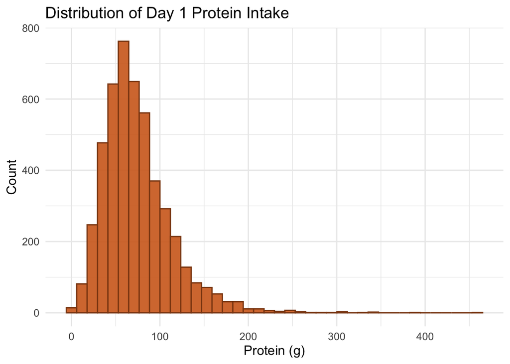

```r
p_hist <- ggplot(nutrient_df, aes(`Protein (g)`)) +
  geom_histogram(
    bins = 40,
    fill = "chocolate",
    color = "chocolate4",
    alpha = 0.9
  ) +
  labs(
    title = "Distribution of Day 1 Protein Intake",
    x = "Protein (g)",
    y = "Count"
  ) +
  theme_minimal(base_size = 13)

p_hist
```

*2) Boxplot — Protein (overall)*

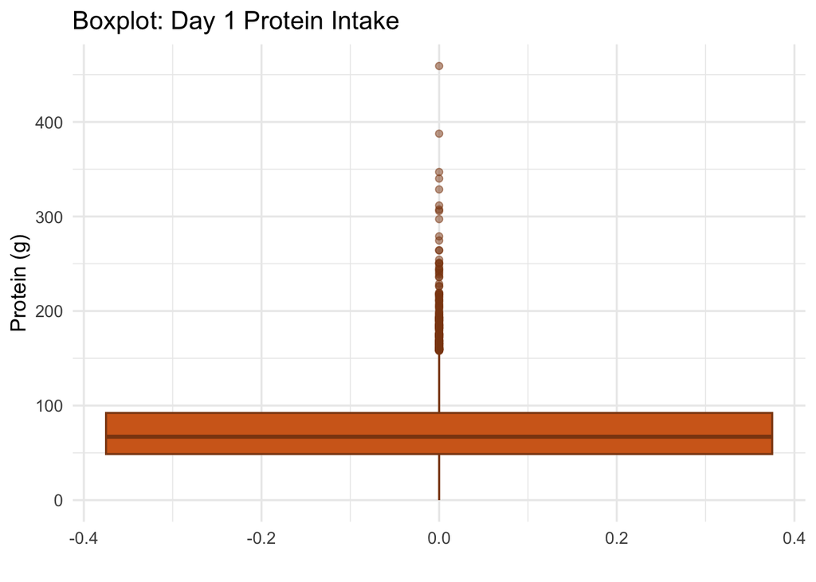

```r
p_box <- ggplot(nutrient_df, aes(y = `Protein (g)`)) +
  geom_boxplot(
    fill = "chocolate",
    color = "chocolate4",
    outlier.alpha = 0.5
  ) +
  labs(
    title = "Boxplot: Day 1 Protein Intake",
    x = "",
    y = "Protein (g)"
  ) +
  theme_minimal(base_size = 13)

p_box
```

*3) Q–Q Plot — Protein (overall)*

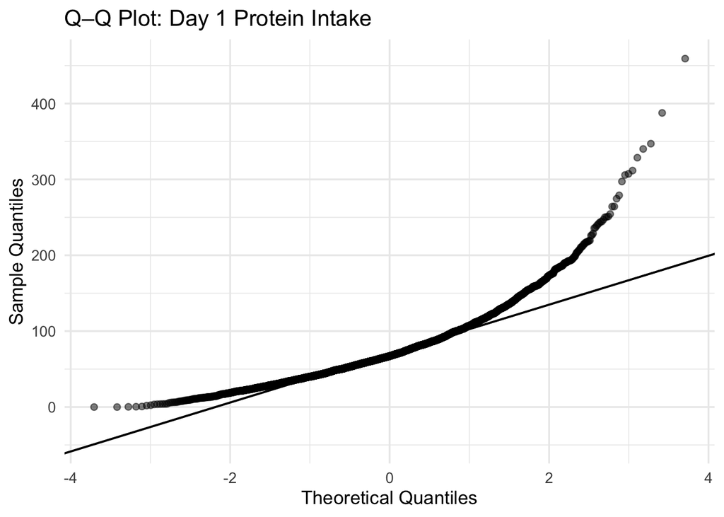

```r
p_qq <- ggplot(nutrient_df, aes(sample = `Protein (g)`)) +
  stat_qq(alpha = 0.5) +
  stat_qq_line(linewidth = 0.7) +
  labs(
    title = "Q–Q Plot: Day 1 Protein Intake",
    x = "Theoretical Quantiles",
    y = "Sample Quantiles"
  ) +
  theme_minimal(base_size = 13)

p_qq
```

Interpretation:

In essence, the data are heavily right-skewed, consistent with the histogram and boxplot, meaning that most people consume moderate amounts of protein while a smaller group reports very high values.

### E. Protein by Gender

First, we create a simple gender label and summarize mean and 95% CI.

```r
# make a simple gender label (1 = Male, 2 = Female in NHANES)
gender_df <- nutrient_df |>
  mutate(gender = case_when(
    RIAGENDR == 1 ~ "Male",
    RIAGENDR == 2 ~ "Female",
    .default = NA_character_
  ))

prot_gender_summary <- gender_df |>
  filter(!is.na(gender)) |>
  group_by(gender) |>
  summarise(
    n = n(),
    mean = mean(`Protein (g)`, na.rm = TRUE),
    sd = sd(`Protein (g)`, na.rm = TRUE),
    se = sd / sqrt(n),
    ci_low = mean - 1.96 * se,
    ci_high = mean + 1.96 * se,
    .groups = "drop"
  )

prot_gender_summary
```

| gender | n | mean | sd | se | ci_low | ci_high |
| --- | --- | --- | --- | --- | --- | --- |
| Female | 2646 | 64.49089 | 31.16488 | 0.6058576 | 63.30341 | 65.67837 |
| Male | 2114 | 86.77245 | 44.29746 | 0.9634436 | 84.88410 | 88.66080 |

*Mean ± 95% CI (by Gender)*

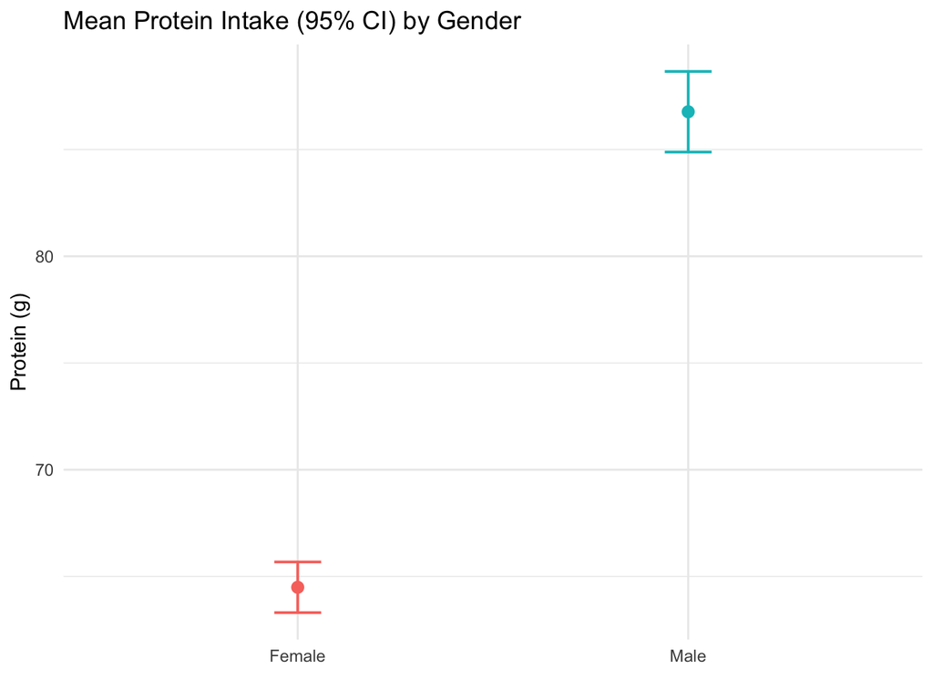

```r
# Plot mean protein intake by gender with 95% confidence intervals
p_ci <- ggplot(prot_gender_summary, aes(x = gender, y = mean, color = gender)) +
  geom_point(size = 3) +
  geom_errorbar(aes(ymin = ci_low, ymax = ci_high),
                width = 0.12, linewidth = 0.8) +
  labs(
    title = "Mean Protein Intake (95% CI) by Gender",
    x = "",
    y = "Protein (g)"
  ) +
  theme_minimal(base_size = 13) +
  theme(legend.position = "none")

# Display the plot in the knitted document
p_ci
```

Interpretation:

*Overlapping Histogram — Protein by Gender (Red/Blue)*

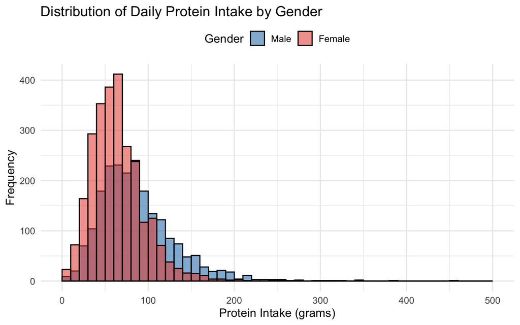

```r
# 1) Make a clean gender factor (1 = Male, 2 = Female)
food <- food |>
  dplyr::mutate(gender = factor(RIAGENDR, levels = c(1, 2),
                                labels = c("Male", "Female")))

# 2) Overlapping histogram (red/blue)
library(ggplot2)
ggplot(dplyr::filter(food, !is.na(gender)),
       aes(x = DR1IPROT_sum, fill = gender)) +
  geom_histogram(breaks = seq(0, 500, by = 10),
                 position = "identity",   # overlap instead of stack
                 alpha = 0.55,            # see-through bars
                 color = "black") +
  scale_fill_manual(values = c(Male = "#1f77b4", Female = "#e74c3c"),
                    name = "Gender") +
  labs(title = "Distribution of Daily Protein Intake by Gender",
       x = "Protein Intake (grams)", y = "Frequency") +
  theme_minimal(base_size = 13) +
  theme(legend.position = "top")
```

Interpretation:

- The distribution for both men and women is right-skewed, meaning most individuals consume moderate amounts of protein, while a few consume much higher quantities.
- Men (blue) tend to consume more protein overall, their distribution shifts slightly to the right compared to women, with a noticeable tail extending toward higher intake levels.
- Women (red) show a lower mean protein intake, clustering around 50–80 grams per day, whereas men more frequently fall between 70–110 grams per day.
- Both distributions overlap substantially, indicating shared dietary patterns, but the difference in central tendency aligns with physiological and caloric differences between genders.

Overall, the figure illustrates that while protein consumption patterns are broadly similar, men on average consume more protein per day than women.

### EDA Summary Protein by Gender

Summarizing the findings in four graphs using patchwork

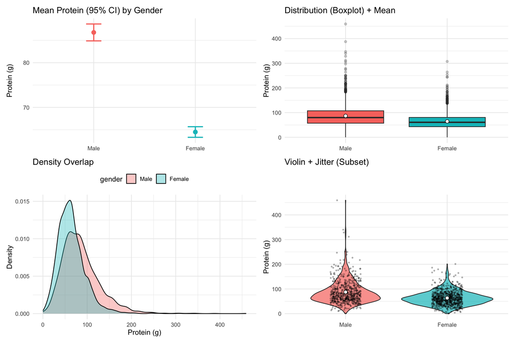

```r
# packages (if not already loaded)


# --- 1) tidy data -----------------------------------------------------------
# RIAGENDR: 1 = Male, 2 = Female; DR1IPROT_sum = total protein (g)
prot_df <- food %>%
  transmute(
    gender = factor(if_else(RIAGENDR == 1, "Male", "Female"),
                    levels = c("Male", "Female")),
    protein = DR1IPROT_sum
  ) %>%
  filter(!is.na(gender), !is.na(protein))

# --- 2) compute mean + 95% CI (for point+CI panel) -------------------------
prot_gender_summary <- prot_df %>%
  group_by(gender) %>%
  summarise(
    n   = n(),
    mean = mean(protein),
    sd   = sd(protein),
    se   = sd / sqrt(n),
    tcrit = qt(0.975, df = n - 1),
    ci_low  = mean - tcrit * se,
    ci_high = mean + tcrit * se,
    .groups = "drop"
  )

# --- 3) four complementary views -------------------------------------------

# A) Mean with 95% CI (clean effect view)
p_ci <- ggplot(prot_gender_summary, aes(x = gender, y = mean, color = gender)) +
  geom_point(size = 3) +
  geom_errorbar(aes(ymin = ci_low, ymax = ci_high), width = 0.15, linewidth = 0.9) +
  labs(title = "Mean Protein (95% CI) by Gender", x = NULL, y = "Protein (g)") +
  theme_minimal(base_size = 12) +
  theme(legend.position = "none")

# B) Boxplot + mean dots (distribution + center)
p_box <- ggplot(prot_df, aes(x = gender, y = protein, fill = gender)) +
  geom_boxplot(outlier.alpha = 0.25) +
  stat_summary(fun = mean, geom = "point", shape = 21, size = 2.5, fill = "white") +
  labs(title = "Distribution (Boxplot) + Mean", x = NULL, y = "Protein (g)") +
  theme_minimal(base_size = 12) +
  theme(legend.position = "none")

# C) Density overlap (shape of distributions)
p_dens <- ggplot(prot_df, aes(x = protein, fill = gender)) +
  geom_density(alpha = 0.35) +
  labs(title = "Density Overlap", x = "Protein (g)", y = "Density") +
  theme_minimal(base_size = 12) +
  theme(legend.position = "top")

# D) Violin + jitter (spread + individual points sample)
set.seed(42)
p_viol <- ggplot(prot_df %>% sample_n(min(1500, n())),  # subsample for readability
                 aes(x = gender, y = protein, fill = gender)) +
  geom_violin(trim = TRUE, alpha = 0.7) +
  geom_jitter(width = 0.15, alpha = 0.25, size = 0.7) +
  stat_summary(fun = mean, geom = "point", shape = 21, size = 2.5, fill = "white") +
  labs(title = "Violin + Jitter (Subset)", x = NULL, y = "Protein (g)") +
  theme_minimal(base_size = 12) +
  theme(legend.position = "none")

# --- 4) assemble into one figure -------------------------------------------
(p_ci | p_box) / (p_dens | p_viol)
```

This four-panel visualization provides a comprehensive view of daily protein intake by gender, combining several perspectives to illustrate both central tendency and distribution.

Overall interpretation: Across all visualizations, the pattern is consistent—men have a higher mean and wider spread of daily protein intake than women, with women’s intake more concentrated around moderate levels.

## Part II: Hypothesis Testing

### Question: Do women eat less protein than men (on average)?

We’ll run a **one-sided, two-sample Welch t-test** where the alternative hypothesis is that **men > women** in mean daily protein intake (grams).

```r
# Convert gender to readable factor
food$RIAGENDR <- factor(food$RIAGENDR,
                        levels = c(1, 2),
                        labels = c("Male", "Female"))
```

### T-Test (one-sided: Male > Female)

```r
tres <- t.test(DR1IPROT_sum ~ RIAGENDR,
               data = food,
               var.equal = FALSE,     # Welch (default)
               alternative = "greater")  # mean(Male) > mean(Female)
tres
```

```
##
##  Welch Two Sample t-test
##
## data:  DR1IPROT_sum by RIAGENDR
## t = 19.578, df = 3657.7, p-value < 2.2e-16
## alternative hypothesis: true difference in means between group Male and group Female is greater than 0
## 95 percent confidence interval:
##  20.40906      Inf
## sample estimates:
##   mean in group Male mean in group Female
##             86.77245             64.49089
```

Interpretation:

- the test statistic (t = 19.578) is very large, and the p-value is less than 2.2e-16, far below any conventional significance threshold (e.g., < 0.05).
- This means we strongly reject the null hypothesis that the two groups have equal mean protein intake.
- The alternative hypothesis — that men (group 1) consume more protein than women (group 2) — is supported.
- The 95 % confidence interval for the difference in means starts at 20.41 g and extends to infinity, confirming that the difference is both positive and substantial.

**Tidy Summary Table**

```r
tres_tidy <- tidy(tres) %>%
  mutate(across(where(is.numeric), round, 2)) %>%
  rename(
    "Mean Male" = estimate1,
    "Mean Female" = estimate2,
    "Mean Difference (Male - Female)" = estimate,
    "t Statistic" = statistic,
    "p Value (one-sided)" = p.value,
    "CI Lower" = conf.low,
    "CI Upper" = conf.high
  ) %>%
  select(`Mean Male`, `Mean Female`, `Mean Difference (Male - Female)`,
         `CI Lower`, `CI Upper`, `t Statistic`, `p Value (one-sided)`)

tres_tidy
```

| Mean Male | Mean Female | Mean Difference (Male - Female) | CI Lower | CI Upper | t Statistic | p Value (one-sided) |
| --- | --- | --- | --- | --- | --- | --- |
| 86.77 | 64.49 | 22.28 | 20.41 | Inf | 19.58 | 0 |

### ANOVA (Cross-check)

A simple one-way ANOVA with gender confirms the same story (it’s equivalent to a two-sided test of equal means).

```r
anovares <- aov(DR1IPROT_sum ~ RIAGENDR, data = food)
summary(anovares)
```

```
##               Df  Sum Sq Mean Sq F value Pr(>F)
## RIAGENDR       1  583417  583417   413.4 <2e-16 ***
## Residuals   4758 6715221    1411
## ---
## Signif. codes:  0 '***' 0.001 '**' 0.01 '*' 0.05 '.' 0.1 ' ' 1
```

## Overall Interpretation of Results:

A potential limitation lies in **recall bias**, as the 24-hour dietary recalls depend on participants’ memory and may lead to inaccurate reporting of portion sizes. Moreover, using **only a single-day recall** cannot fully capture individuals’ usual intake patterns.

Nevertheless, given the strength and consistency of the statistical results, **we can state with high confidence** that women, on average, consume less protein than men.